# Assignment07

2023-06-08

## Task 1: Get familiar with tidyverse

## Excersise collection: Life expectancy

Vorwarnung: der code von der Website ging nicht, deswegen wird hoffentlich dieselbe Data benutzt (danke an Sofia )

```r
gapminder_raw <- read.csv("https://raw.githubusercontent.com/resbaz/r-novice-gapminder-files/master/data/gapminder-FiveYearData.csv")
#einlesen und ersten Einträge anschauen
head(gapminder_raw)
```

```
##       country year      pop continent lifeExp gdpPercap
## 1 Afghanistan 1952  8425333      Asia  28.801  779.4453
## 2 Afghanistan 1957  9240934      Asia  30.332  820.8530
## 3 Afghanistan 1962 10267083      Asia  31.997  853.1007
## 4 Afghanistan 1967 11537966      Asia  34.020  836.1971
## 5 Afghanistan 1972 13079460      Asia  36.088  739.9811
## 6 Afghanistan 1977 14880372      Asia  38.438  786.1134
```

## Research questions

Is life expectancy related to GDP (Gross Domestic Product)? If so, to what degree (and form)? Is this assocication moderated by continent? –> in general: positive correlation, indicating that higher GDP levels tend to be associated with longer life expectancy –> but this can vary across continents (regional factors and disparities)

## First steps- loading needed library

```r
#install.packages("tidyverse")
library(tidyverse)
```

## 6 Exercises

## 6.1 Data Wrangling

1. Filter the data for the Americas in 2007, deselect all other variables

```r
# Piping: "and then" -> more functions at one
#first filter the needed rows
gapminder_raw %>% filter(continent == "Americas", year=="2007") %>%
#select and show only countries in Americas continent from 2007
select(country, lifeExp)
```

```
##                country lifeExp
## 1            Argentina  75.320
## 2              Bolivia  65.554
## 3               Brazil  72.390
## 4               Canada  80.653
## 5                Chile  78.553
## 6             Colombia  72.889
## 7           Costa Rica  78.782
## 8                 Cuba  78.273
## 9   Dominican Republic  72.235
## 10             Ecuador  74.994
## 11         El Salvador  71.878
## 12           Guatemala  70.259
## 13               Haiti  60.916
## 14            Honduras  70.198
## 15             Jamaica  72.567
## 16              Mexico  76.195
## 17           Nicaragua  72.899
## 18              Panama  75.537
## 19            Paraguay  71.752
## 20                Peru  71.421
## 21         Puerto Rico  78.746
## 22 Trinidad and Tobago  69.819
## 23       United States  78.242
## 24             Uruguay  76.384
## 25           Venezuela  73.747
```

2. Create the variable gdp, defined as the product of population size and gdp per person

```r
# mit allen
gdp <- gapminder_raw$pop * gapminder_raw$gdpPercap
head(gdp)
```

```
## [1]  6567086330  7585448670  8758855797  9648014150  9678553274 11697659231
```

3. Identify the observation with lowest gdp per year

```r
lowest_gdp<- gapminder_raw %>% filter(gdpPercap==min(gdpPercap))
lowest_gdp
```

```
##           country year      pop continent lifeExp gdpPercap
## 1 Congo Dem. Rep. 2002 55379852    Africa  44.966  241.1659
```

4. Identify all observations with above average life expectancy, stratified for each continent –> also für jeden Kontinent einzeln?

```r
avg_life_exp<- gapminder_raw %>% group_by(continent) %>% summarize(avg_life_exp = mean(lifeExp))
data_con_average <- gapminder_raw %>% left_join(avg_life_exp, by = "continent")
above_average<- data_con_average%>% filter(lifeExp> avg_life_exp)
head(above_average)
```

```
##   country year      pop continent lifeExp gdpPercap avg_life_exp
## 1 Albania 1987  3075321    Europe  72.000  3738.933     71.90369
## 2 Albania 1997  3428038    Europe  72.950  3193.055     71.90369
## 3 Albania 2002  3508512    Europe  75.651  4604.212     71.90369
## 4 Albania 2007  3600523    Europe  76.423  5937.030     71.90369
## 5 Algeria 1967 12760499    Africa  51.407  3246.992     48.86533
## 6 Algeria 1972 14760787    Africa  54.518  4182.664     48.86533
```

–> nicht ganz sicher bei der Aufgabe -> fast die Hälfte an ürsprünglichen Reihen

5. Count the observations identified in the last step -> count rows

```r
observations <- nrow(above_average)
head(observations)
```

```
## [1] 873
```

6. Compute the mean life expectancy (grand mean)

```r
grand_mean <- mean(gapminder_raw$lifeExp)
head(grand_mean)
```

```
## [1] 59.47444
```

7. Compute the mean life expectancy for each year

```r
mean_years <- gapminder_raw %>% group_by(year) %>% summarise(mean_years=mean(lifeExp))
head(mean_years)
```

```
## # A tibble: 6 × 2
##    year mean_years
##   <int>      <dbl>
## 1  1952       49.1
## 2  1957       51.5
## 3  1962       53.6
## 4  1967       55.7
## 5  1972       57.6
## 6  1977       59.6
```

## 6.2 Data Visualization

1. Create a scatter plot showing the association of gdp per person and life expectancy

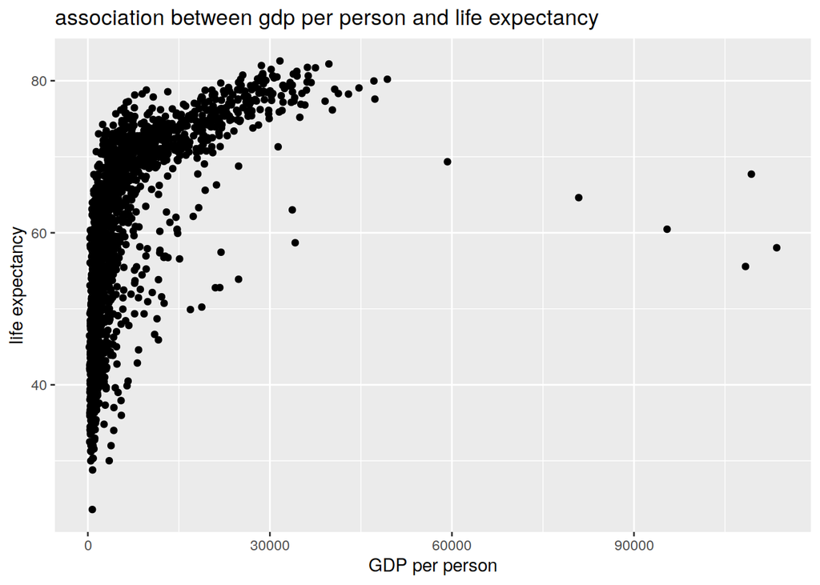

```r
library(ggplot2)
ggplot(gapminder_raw, aes(x= gdpPercap, y=lifeExp)) + geom_point() + labs(x= "GDP per person", y="life expectancy") + ggtitle("association between gdp per person and life expectancy")
```

2. Add a rolling average line (LOESS smoother)

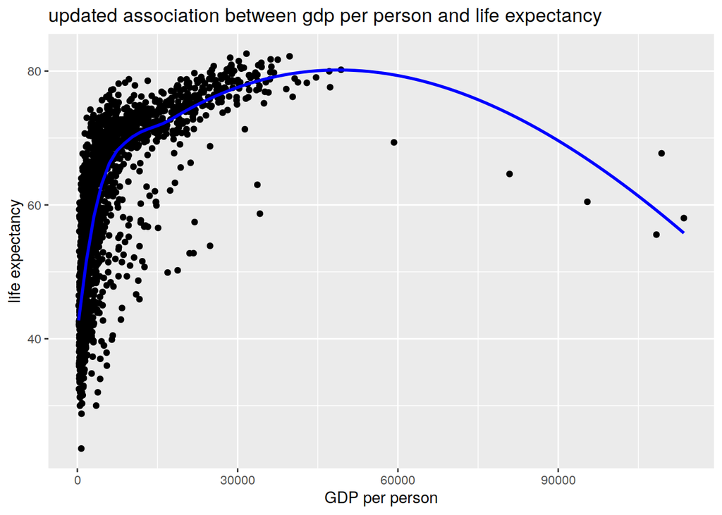

```r
ggplot(gapminder_raw, aes(x= gdpPercap, y=lifeExp)) + geom_point() + geom_smooth(method= "loess", se=FALSE, color="blue") + labs(x= "GDP per person", y="life expectancy") + ggtitle("updated association between gdp per person and life expectancy")
```

3. Add a linear model line

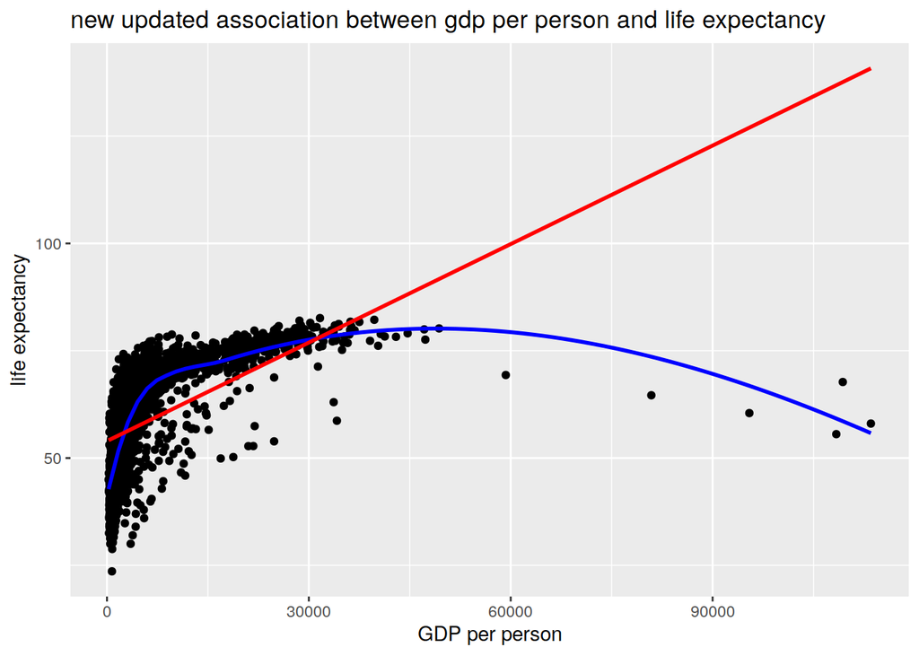

```r
ggplot(gapminder_raw, aes(x= gdpPercap, y=lifeExp)) + geom_point() + geom_smooth(method="loess", se=FALSE, color="blue") + geom_smooth(method= "lm", se=FALSE, color="red") + labs(x= "GDP per person", y="life expectancy") + ggtitle("new updated association between gdp per person and life expectancy")
```

4. Create scatter plot

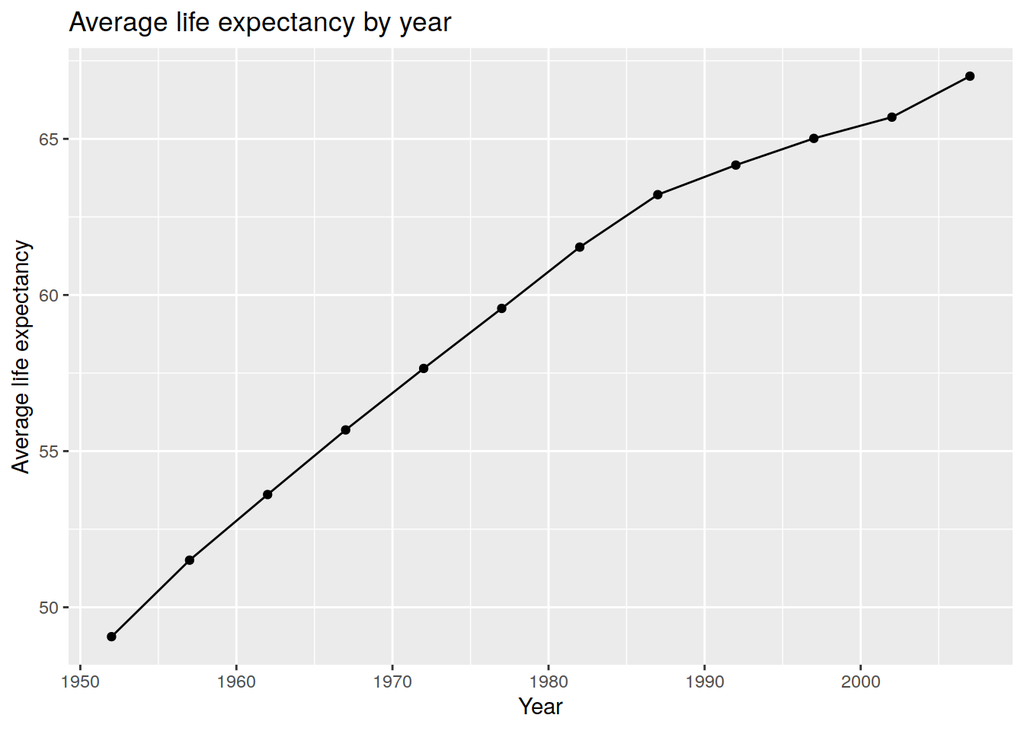

```r
ggplot(mean_years, aes(x=year, y=mean_years)) + geom_point()+geom_line()+labs(x="Year", y="Average life expectancy")+ ggtitle("Average life expectancy by year")
```

5. Modify the last plot so that there is a line for each continent

```r
mean_years_continent <- gapminder_raw %>% group_by(year, continent) %>% summarize(mean_years =mean(lifeExp))
```

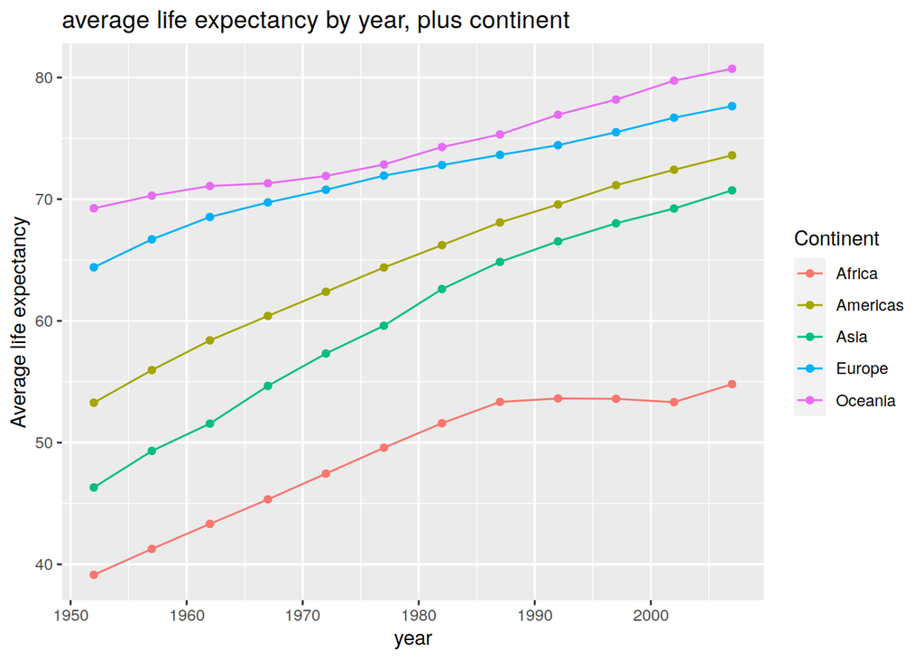

```r
ggplot(mean_years_continent, aes(x=year, y=mean_years, color=continent, group=continent))+ geom_point() + geom_line() +labs(x="year", y="Average life expectancy", color="Continent")+ ggtitle("average life expectancy by year, plus continent ")
```

6. Create a scatter plot showing the association of gdp per person and life expectancy

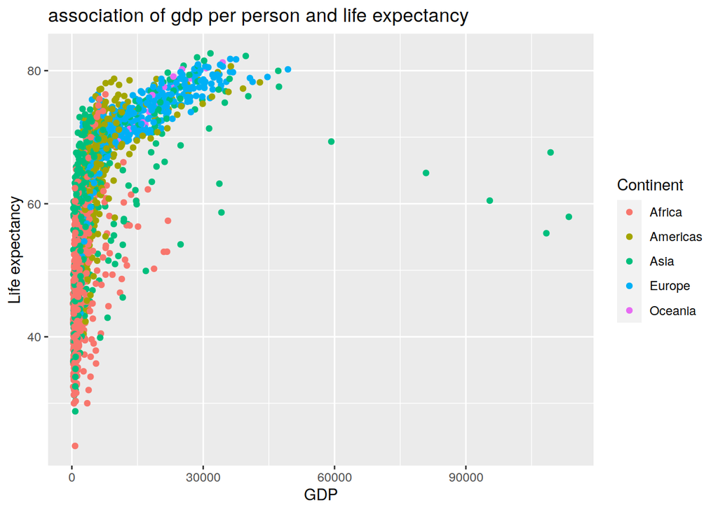

```r
ggplot(gapminder_raw, aes(x=gdpPercap, y=lifeExp, color=continent)) + geom_point() + labs(x= "GDP", y="Life expectancy", color="Continent") + ggtitle("association of gdp per person and life expectancy")
```

7. Modify last plot so that the size of the dots represents the population size. in addition, increase the transparency of the dots in order to mitigate overplotting

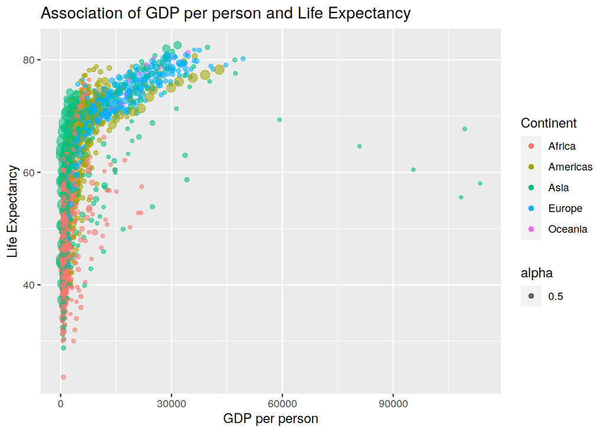

```r
ggplot(gapminder_raw, aes(x = gdpPercap, y = lifeExp, color = continent, size = pop, alpha = 0.5)) +
  geom_point() +
  labs(x = "GDP per person", y = "Life Expectancy", color = "Continent", size = "Population") +
  ggtitle("Association of GDP per person and Life Expectancy") +
  guides(size = "none")
```

8. Modify last plot so that there is a facet for each continent -> using facet wrap

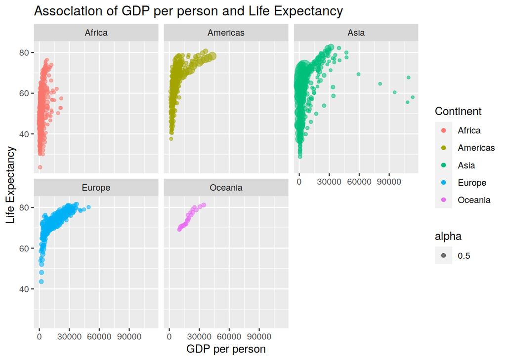

```r
ggplot(gapminder_raw, aes(x = gdpPercap, y = lifeExp, color = continent, size = pop, alpha = 0.5)) +
  geom_point() +
  labs(x = "GDP per person", y = "Life Expectancy", color = "Continent", size = "Population") +
  ggtitle("Association of GDP per person and Life Expectancy") +
  facet_wrap(~ continent, nrow = 2) +
  guides(size = "none")
```

9. Modify the last plot so that GDP is log transformed

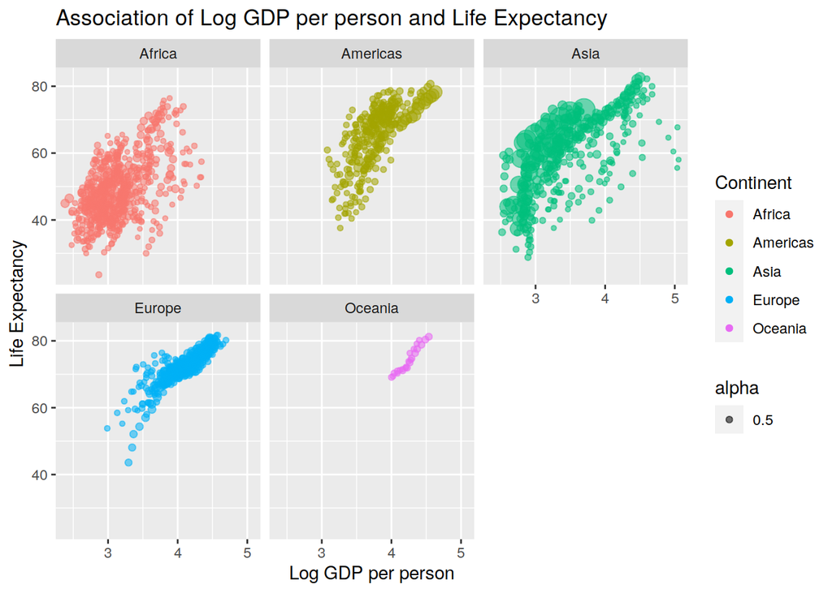

```r
ggplot(gapminder_raw, aes(x = log10(gdpPercap), y = lifeExp, color = continent, size = pop, alpha = 0.5)) +
  geom_point() +
  labs(x = "Log GDP per person", y = "Life Expectancy", color = "Continent", size = "Population") +
  ggtitle("Association of Log GDP per person and Life Expectancy") +
  facet_wrap(~ continent, nrow = 2) +
  guides(size = "none")
```

## Task 2: Recap 1: Yeast GTF

## Give information about how many chromosome, features and subfeature entries are given in the gtf-file. How many entries of each type are in the gtf?

counts of chromosome, feature, subfeature and type entries:

```r
gtf_df %>%
  count(seqnames)
```

```
##    seqnames    n
## 1         I  744
## 2        II 2867
## 3       III 1174
## 4        IV 5290
## 5         V 2081
## 6        VI  916
## 7       VII 3739
## 8      VIII 2027
## 9        IX 1537
## 10        X 2542
## 11       XI 2174
## 12      XII 3708
## 13     XIII 3236
## 14      XIV 2726
## 15       XV 3765
## 16      XVI 3239
## 17     Mito  306
```

```r
gtf_df %>%
  count(gene_biotype)
```

```
##     gene_biotype     n
## 1          ncRNA    45
## 2 protein_coding 40700
## 3     pseudogene    65
## 4           rRNA    53
## 5          snRNA    18
## 6         snoRNA   233
## 7           tRNA   957
```

```r
gtf_df %>%
  count(gene_id) %>% #not sure what subfeature means here.
  head
```

```
##    gene_id n
## 1 15S_rRNA 3
## 2 21S_rRNA 4
## 3     HRA1 3
## 4     ICR1 3
## 5     LSR1 3
## 6     NME1 3
```

```r
gtf_df %>%
  count(type)
```

```
##          type    n
## 1        gene 7126
## 2  transcript 7126
## 3        exon 7553
## 4         CDS 7050
## 5 start_codon 6700
## 6  stop_codon 6516
```

Is the amount of features on the ’+’-strand the same as on the ’-’-strand? Is the amount the same on each chromosome? The amount of features is not the same. And the amount on each chromosome is also different.

```r
gtf_df %>%
  group_by(seqnames) %>%
  count(strand) %>%
  ungroup()
```

```
## # A tibble: 34 × 3
##    seqnames strand     n
##    <fct>    <fct>  <int>
##  1 I        +        386
##  2 I        -        358
##  3 II       +       1364
##  4 II       -       1503
##  5 III      +        527
##  6 III      -        647
##  7 IV       +       2572
##  8 IV       -       2718
##  9 V        +       1027
## 10 V        -       1054
## # ℹ 24 more rows
```

Plot the length distribution of each feature (gene, cds, start-codon,…)

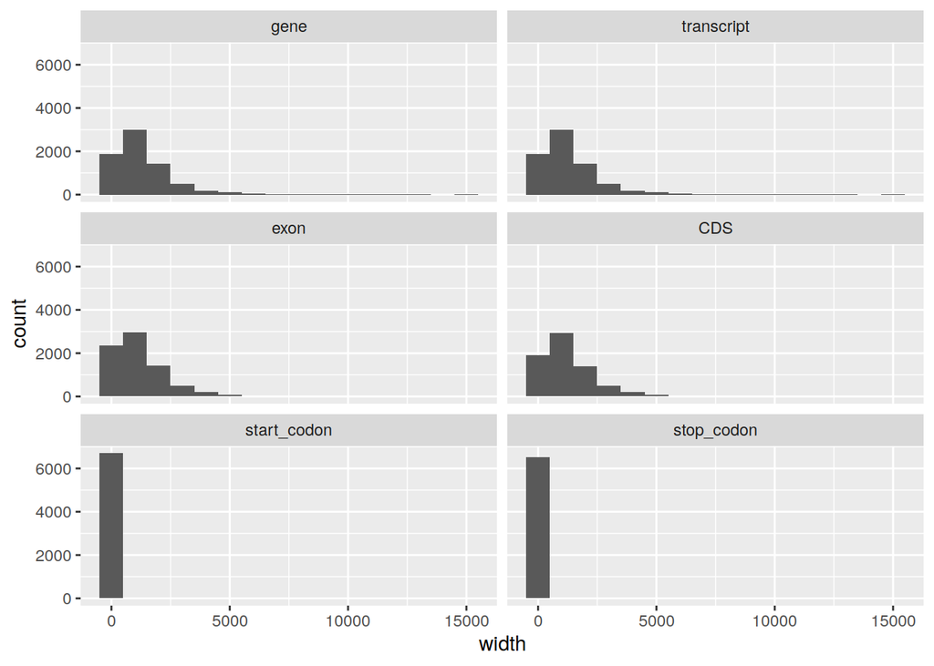

```r
gtf_df %>%
  ggplot() +
  geom_histogram(aes(x = width), binwidth = 1000) +
  facet_wrap(~type, ncol = 2)
```

Plot the relationship of each subfeature to the feature. E.g. how many transcripts are there per gene, are there transcripts with more than one exon? One gene only has one start_codon and one stop_codon, so we could ignore them.

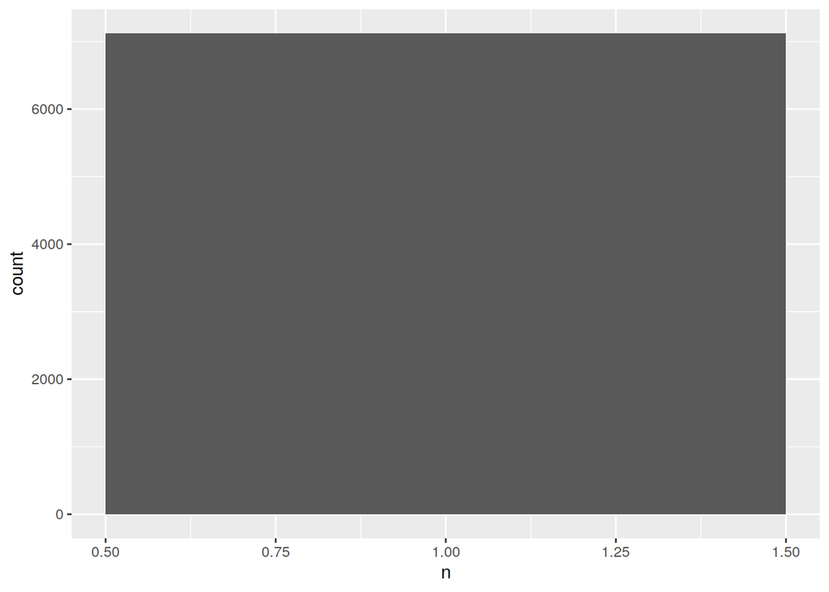

```r
gtf_df %>%
  filter(type == "transcript") %>%
  group_by(gene_id) %>%
  count(type) %>%
  ungroup() %>%
  as.data.frame() %>%
  ggplot() +
  geom_histogram(aes(x = n), binwidth = 1)
```